# Business case study

### A business sells cloths online.Customers walk in the store, have meetings with the personal stylist and then they go home and order online either on the mobile app or the website

## Business problem statement

### The business is trying to decide on whether to develope the mobile app or the website since it does not have the funds to do both.

## Machine learning solution

### The following is an ML based prediction analysis for the company to use to build a model to determine whether they should focus on the mobile app or website.This analysis may also provide other business insights that can help improve customer understanding and lead to appropriate business actions

### importing necessary libraries

```python
import pandas as pd
import numpy as np
import matplotlib.pyplot as plt
%matplotlib inline
```

### reading in csv file

```python
customers=pd.read_csv('Ecommerce.csv')

customers.head()
```

|  | Email | Address | Avatar | Avg. Session Length | Time on App | Time on Website | Length of Membership | Yearly Amount Spent |
| --- | --- | --- | --- | --- | --- | --- | --- | --- |
| 0 | mstephenson@fernandez.com | 835 Frank Tunnel\r\nWrightmouth, MI 82180-9605 | Violet | 34.497268 | 12.655651 | 39.577668 | 4.082621 | 587.951054 |
| 1 | hduke@hotmail.com | 4547 Archer Common\r\nDiazchester, CA 06566-8576 | DarkGreen | 31.926272 | 11.109461 | 37.268959 | 2.664034 | 392.204933 |
| 2 | pallen@yahoo.com | 24645 Valerie Unions Suite 582\r\nCobbborough,... | Bisque | 33.000915 | 11.330278 | 37.110597 | 4.104543 | 487.547505 |
| 3 | riverarebecca@gmail.com | 1414 David Throughway\r\nPort Jason, OH 22070-... | SaddleBrown | 34.305557 | 13.717514 | 36.721283 | 3.120179 | 581.852344 |
| 4 | mstephens@davidson-herman.com | 14023 Rodriguez Passage\r\nPort Jacobville, PR... | MediumAquaMarine | 33.330673 | 12.795189 | 37.536653 | 4.446308 | 599.406092 |

### using the describe function to find all the data distribution information

```python
customers.describe()
```

|  | Avg. Session Length | Time on App | Time on Website | Length of Membership | Yearly Amount Spent |
| --- | --- | --- | --- | --- | --- |
| count | 500.000000 | 500.000000 | 500.000000 | 500.000000 | 500.000000 |
| mean | 33.053194 | 12.052488 | 37.060445 | 3.533462 | 499.314038 |
| std | 0.992563 | 0.994216 | 1.010489 | 0.999278 | 79.314782 |
| min | 29.532429 | 8.508152 | 33.913847 | 0.269901 | 256.670582 |
| 25% | 32.341822 | 11.388153 | 36.349257 | 2.930450 | 445.038277 |
| 50% | 33.082008 | 11.983231 | 37.069367 | 3.533975 | 498.887875 |
| 75% | 33.711985 | 12.753850 | 37.716432 | 4.126502 | 549.313828 |
| max | 36.139662 | 15.126994 | 40.005182 | 6.922689 | 765.518462 |

### using.info to find the data types of all the columns

```python
customers.info()
```

```
<class 'pandas.core.frame.DataFrame'>
RangeIndex: 500 entries, 0 to 499
Data columns (total 8 columns):
 #   Column                Non-Null Count  Dtype
---  ------                --------------  -----
 0   Email                 500 non-null    object
 1   Address               500 non-null    object
 2   Avatar                500 non-null    object
 3   Avg. Session Length   500 non-null    float64
 4   Time on App           500 non-null    float64
 5   Time on Website       500 non-null    float64
 6   Length of Membership  500 non-null    float64
 7   Yearly Amount Spent   500 non-null    float64
dtypes: float64(5), object(3)
memory usage: 31.4+ KB
```

## Exploratory data analysis

### H<sub>0</sub> = develope the app and H<sub>1</sub> = develope the website

```python
import seaborn as sns
```

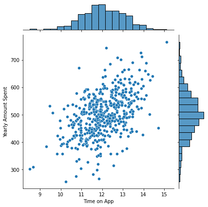

```python
sns.jointplot(customers['Time on App'],customers['Yearly Amount Spent'])
```

### plotting a 2D hex plot to see the density or clustering of the points

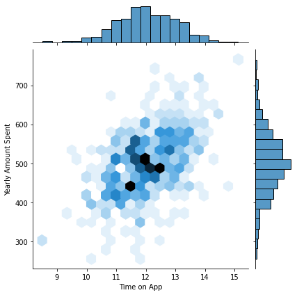

```python
sns.jointplot(customers['Time on App'],customers['Yearly Amount Spent'], kind='hex')
```

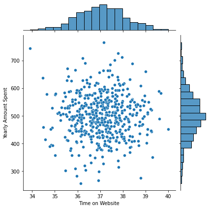

```python
sns.jointplot(customers['Time on Website'],customers['Yearly Amount Spent'])
```

### Time spent on app appears to have some correlation to yearly amount spent while time on website doesn't

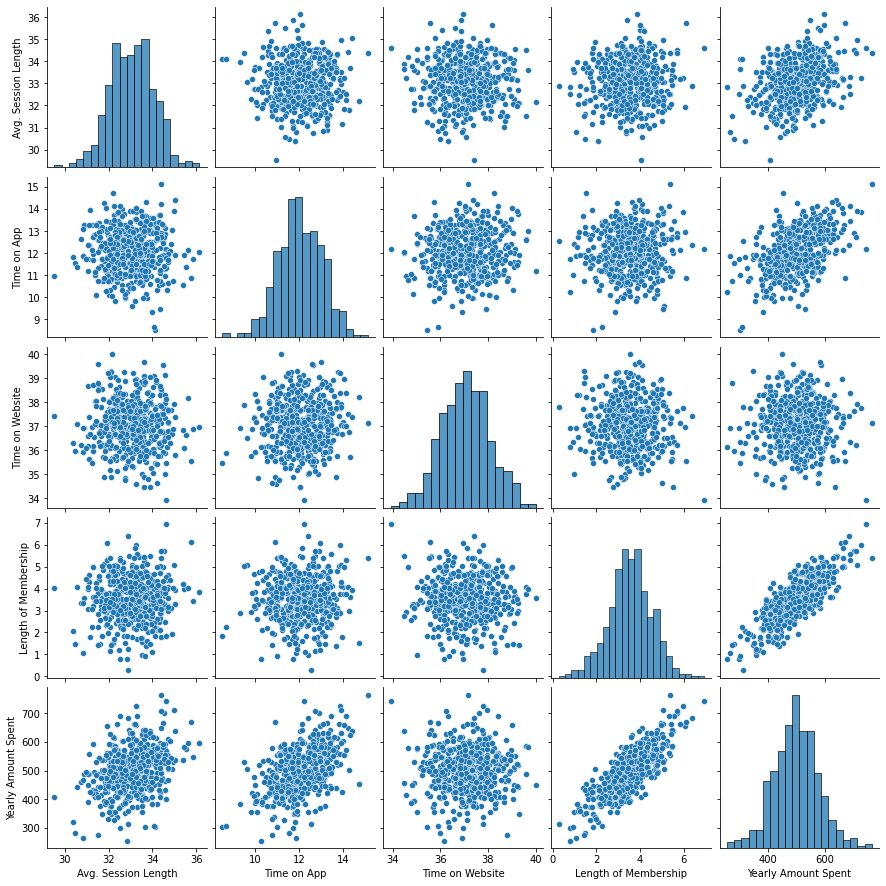

```python
sns.pairplot(customers)
```

### The pair plots above show that length of membership has the strongest correlation to yearly amount spent than the the other features.

### Using seaborns lmplot to create a linear model plot of yearly amount spent and length of membership

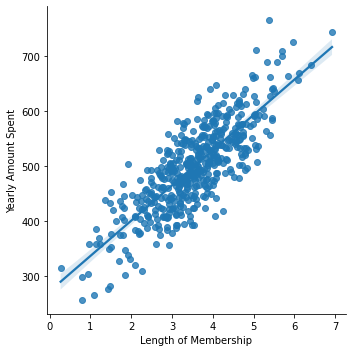

```python
sns.lmplot(x='Length of Membership',y='Yearly Amount Spent', data=customers)
```

## Training and testing the data

### in the next steps the data is split into training data and test data. the variable x is used for the numerical values of the customers data set excluding yearly amount spent and yearly amount spent is assigned to y.

```python
y= customers['Yearly Amount Spent']
```

```python
x= customers[['Length of Membership','Time on App','Time on Website','Avg. Session Length']]
```

```python
import sys
!{sys.executable} -m pip install sklearn
```

### random_state is used to ensure that you can get the same sequence by specifying the number

```python
from sklearn.model_selection import train_test_split
x_train, x_test, y_train, y_test= train_test_split(x, y, test_size=0.3, random_state=101)
```

## Training the data

```python
from sklearn.linear_model import LinearRegression
```

```python
# create an instance of the LinearRegression n.b - we are using the linear regression algorithm to train our data

lm=LinearRegression()
```

```python
# train or fit the data
lm.fit(x_train,y_train)
```

```
LinearRegression()
```

### the fit just calculates the values of the parameters but does not apply them to the actual data while the fit_transform does the calculation and applies it to the data in one step.

```python
print('coefficients: \n', lm.coef_)
```

```
coefficients:
 [61.27909654 38.59015875  0.19040528 25.98154972]
```

### the regression coefficient describes the size and direction of the relationship between the predictor variable and the response variable

## Predicting Test data

```python
predictions=lm.predict(x_test)
```

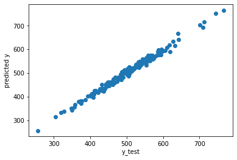

```python
# plotting a scatter plot of y_test verses predictions
plt.scatter(y_test,predictions)
plt.xlabel('y_test')
plt.ylabel('predicted y')
```

## Model evaluation

### calculate the Mean absolute error,Mean squared error,Root mean squared error

```python
from sklearn import metrics

print('MAE:',metrics.mean_absolute_error(y_test,predictions))
print('MSE:',metrics.mean_squared_error(y_test,predictions))
print('RMSE:',np.sqrt(metrics.mean_squared_error(y_test,predictions)))
```

```
MAE: 7.228148653430834
MSE: 79.81305165097454
RMSE: 8.933815066978639
```

### plot a distplot of the errors to see whether they are normally distributed

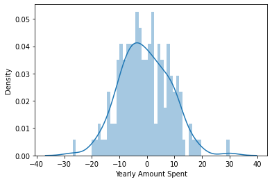

```python
sns.distplot(y_test-predictions, bins= 50)
```

## Conclusion

### the coefficients will give us the answer on whether the company need to focus on the mobile app or the website

```python
coefficients=pd.DataFrame(lm.coef_,x.columns)
coefficients.columns = ['coefficients']
coefficients
```

|  | coefficients |
| --- | --- |
| Length of Membership | 61.279097 |
| Time on App | 38.590159 |
| Time on Website | 0.190405 |
| Avg. Session Length | 25.981550 |

### We should develop the App though the coefficients show that length of membership has the most effect on the yearly amount spent at the store by customers